# 分析结果附件

Kang

2022-12-22

## 1 概述

内部改稿，我这里主要工作包括： (1) 出不同土地利用下的ESV图表； (2) 不同土地利用下树木各属性的均值或中位数； (3) 修改树木属性计算部分的方法和结果； (4) 回复平林关于绝对误差的评论

## 2 方法和结果

### 2.1 不同土地利用下的ESV

不同土地利用下的ES比较。原稿的图有误（这个我们讨论过），所以我重新计算并作图了：

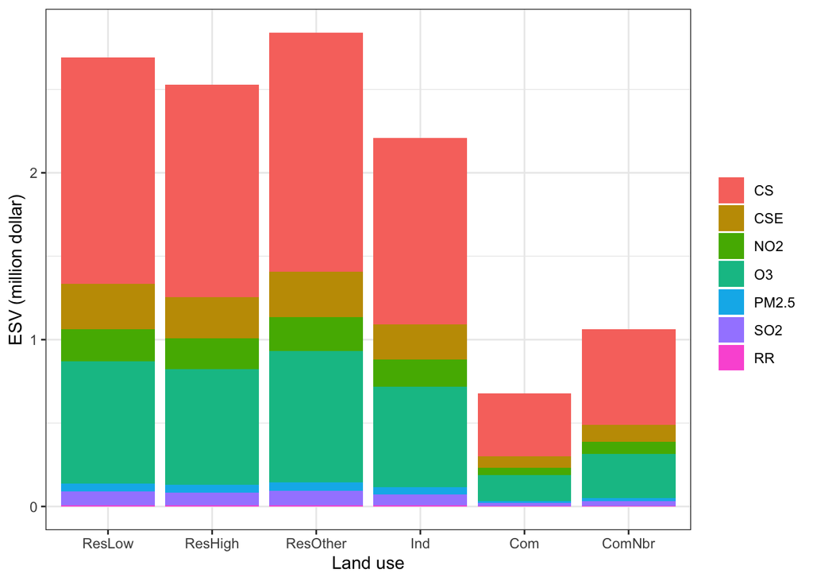

对应数值为：

| landuse | qua_num | richness | density | dbh_mean | dbh_mid | height_mean | height_mid | lai_mean | lai_mid | carbon_stor_val | carbon_seq_val | no2_rem_val | o3_rem_val | pm25_rem_val | so2_rem_val | ro_rd_val |
| --- | --- | --- | --- | --- | --- | --- | --- | --- | --- | --- | --- | --- | --- | --- | --- | --- |
| Com | 12 | 22 | 3.666667 | 14.16011 [cm] | 9.750000 [cm] | 4.443182 [m] | 3.35 [m] | 3.128193 [1] | 2.649402 [1] | 377965.7 [dollar] | 66912.23 [dollar] | 43708.39 [dollar] | 157651.5 [dollar] | 10601.76 [dollar] | 18696.54 [dollar] | 1674.550 [dollar] |
| ComNbr | 9 | 18 | 8.555556 | 11.28139 [cm] | 7.000000 [cm] | 4.355844 [m] | 2.70 [m] | 3.141240 [1] | 2.543326 [1] | 575582.8 [dollar] | 100832.88 [dollar] | 70929.48 [dollar] | 267101.7 [dollar] | 16544.85 [dollar] | 29988.31 [dollar] | 2588.993 [dollar] |
| Ind | 23 | 43 | 5.826087 | 14.06855 [cm] | 11.090170 [cm] | 5.534328 [m] | 4.00 [m] | 3.055815 [1] | 2.489630 [1] | 1116609.5 [dollar] | 210288.98 [dollar] | 161832.05 [dollar] | 602338.0 [dollar] | 42323.42 [dollar] | 67187.37 [dollar] | 6576.047 [dollar] |
| ResHigh | 38 | 77 | 9.684211 | 11.90080 [cm] | 8.831579 [cm] | 4.345109 [m] | 3.00 [m] | 3.622993 [1] | 3.132989 [1] | 1272813.1 [dollar] | 249660.82 [dollar] | 184082.67 [dollar] | 694066.3 [dollar] | 44338.70 [dollar] | 77190.15 [dollar] | 6842.500 [dollar] |
| ResLow | 35 | 81 | 11.400000 | 10.22511 [cm] | 7.000000 [cm] | 4.333835 [m] | 2.90 [m] | 3.875620 [1] | 3.514801 [1] | 1356091.5 [dollar] | 272354.75 [dollar] | 194201.03 [dollar] | 731865.0 [dollar] | 45990.26 [dollar] | 83544.40 [dollar] | 7114.637 [dollar] |
| ResOther | 34 | 68 | 6.411765 | 15.02720 [cm] | 8.000000 [cm] | 4.906422 [m] | 3.55 [m] | 3.142666 [1] | 2.922134 [1] | 1432022.5 [dollar] | 272903.86 [dollar] | 205016.03 [dollar] | 785665.6 [dollar] | 50768.15 [dollar] | 86537.13 [dollar] | 7801.288 [dollar] |

### 2.2 不同土地利用下的树木属性

从整个城市整体数据来看，概况：

```
##
##  total species: 133
##  total genera: 96
##  total families: 50
##
```

然后分土地利用进行对比，这里的树木属性包括树木大小、树木多少、生物多样性，相关解释见Word文档。

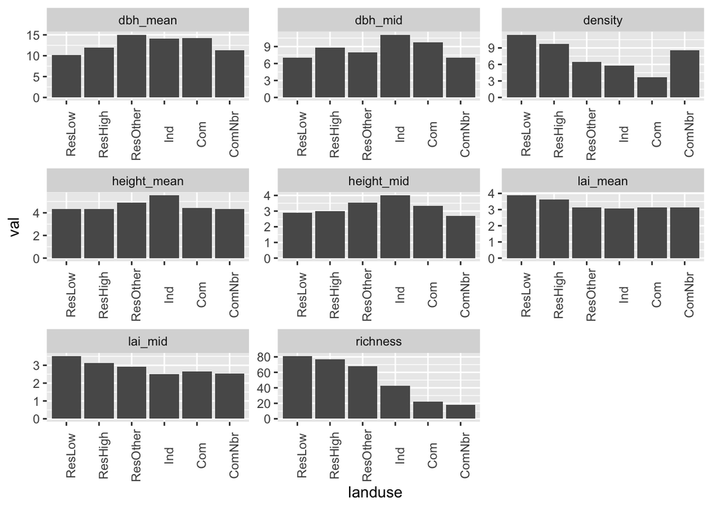

### 2.3 修改树木属性部分正文

见稿件。主要修改了：树木属性计算方法描述，替代原本的生物多样性计算内容；ES计算正文部分简化和重构；以上两部分的相关结果。

### 2.4 回复平林绝对误差评论

| rowid | CS | CSE | NO2 | O3 | PM2.5 | SO2 | RR |
| --- | --- | --- | --- | --- | --- | --- | --- |
| 1 | 1328.8861 | 40.32823 | 116.96387 | 369.9238 | 26.821442 | 58.12705 | 4.719690 |
| 2 | 5665.1062 | 142.02228 | 389.94598 | 1151.2233 | 66.933661 | 160.26248 | 11.161409 |
| 3 | 657.0211 | 62.64522 | 134.11499 | 415.5742 | 26.006726 | 48.25982 | 4.166885 |
| 4 | 714.4304 | 58.85237 | 41.15463 | 136.8205 | 8.781345 | 17.38129 | 1.428486 |
| 5 | 385.3027 | 29.39225 | 57.99714 | 154.9034 | 9.782490 | 24.17581 | 1.813037 |
| 6 | 608.6626 | 52.20874 | 43.38421 | 143.5726 | 8.694129 | 17.90446 | 1.397332 |

对于每种插值方法下的每种ES，可以做绝对误差的分布图，以EBK为例：

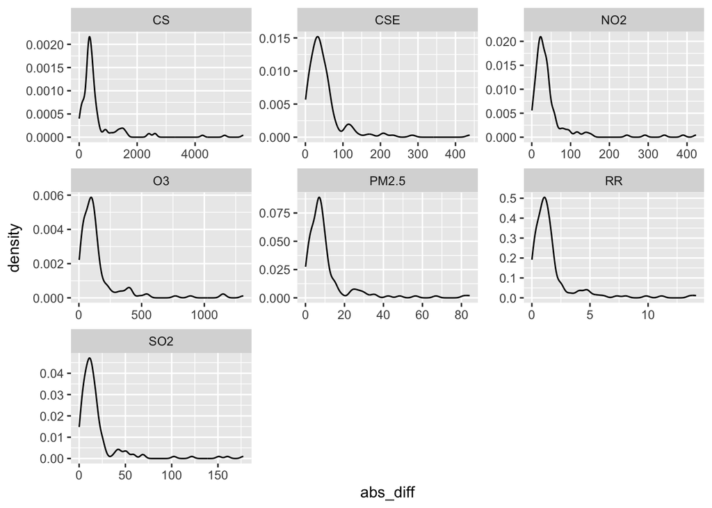

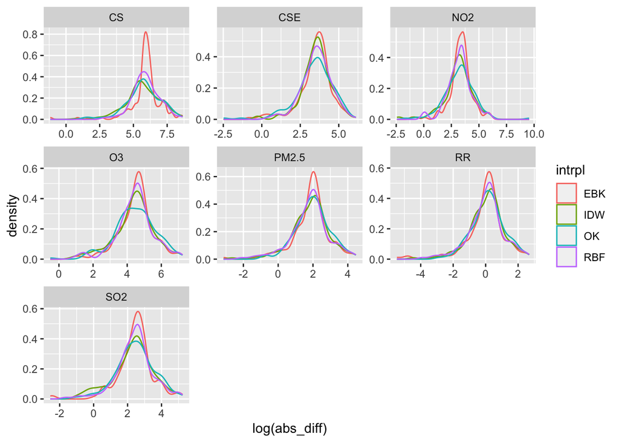

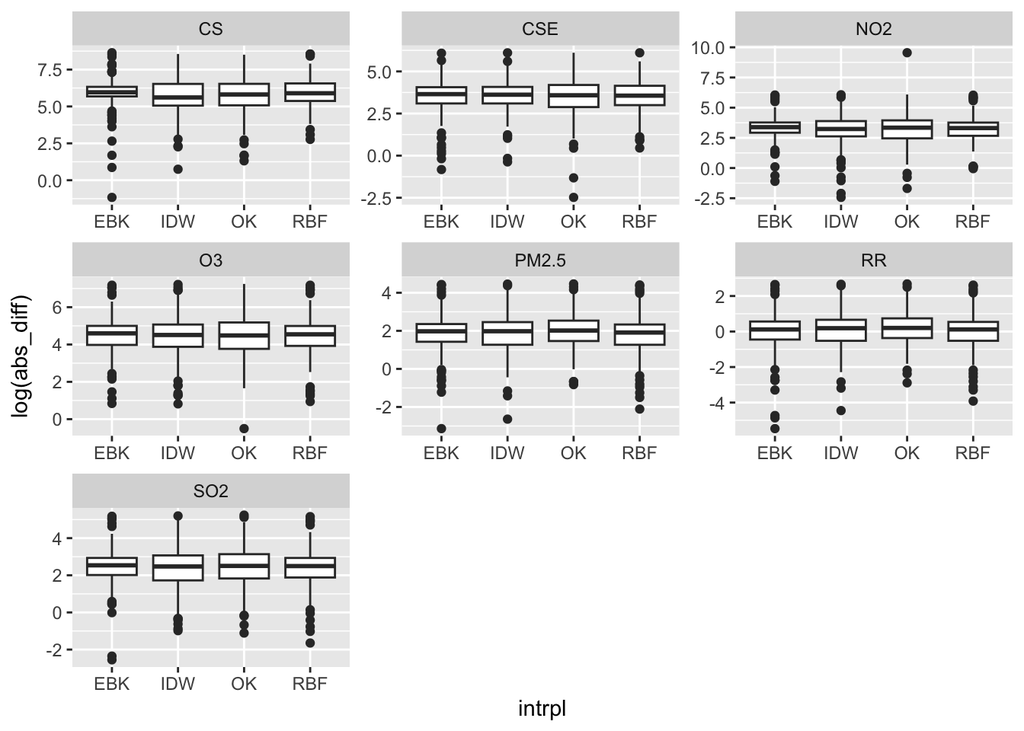

这个就很微妙了……EBK并不比其他方法好，但是这个是总体情况，如果做配对比较的话可能会不一样，我再考虑一下。 不如把每个点拎出来，看看其他方法的绝对误差相比于EBK的是否更大。在这个思路下，计算对于每个样点而言，其他方法各种ES的绝对误差相对于EBK的差值，并可视化。

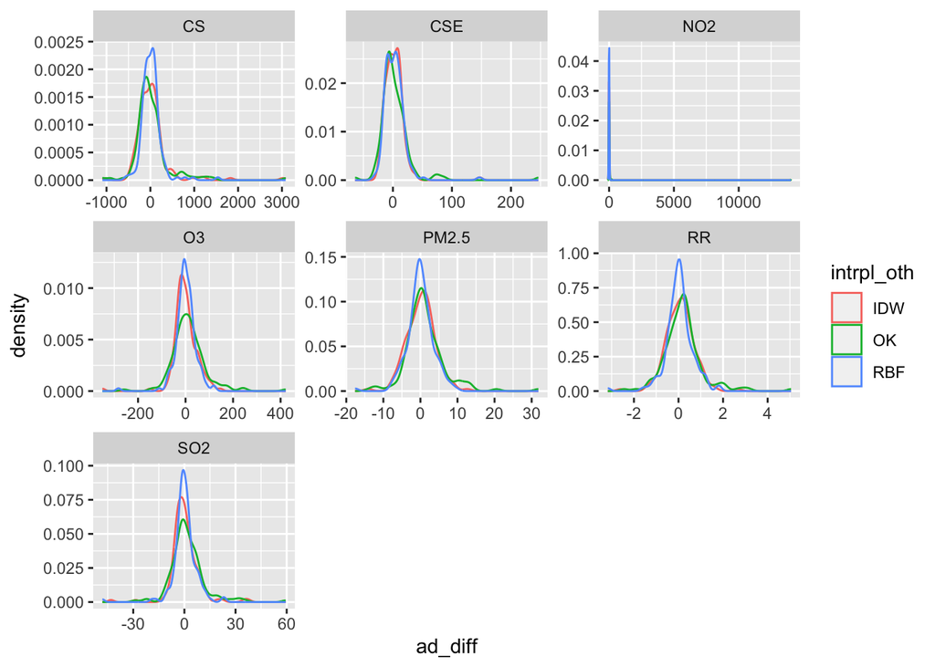

好吧，其实差异还是很小，大部分差异都集中在0附近（如果一个绝对误差的差值为0，就说明两种方法在在这个样点上的表现相同；如果大于0，说明EBK的绝对误差更小，也就是说表现更好。理想情况下，如果EBK在大部分样点上的表现都更好，这个图中的各曲线应该要往右偏才对）。盒形图的结果也是如此，基本上中位数就集中在0左右。

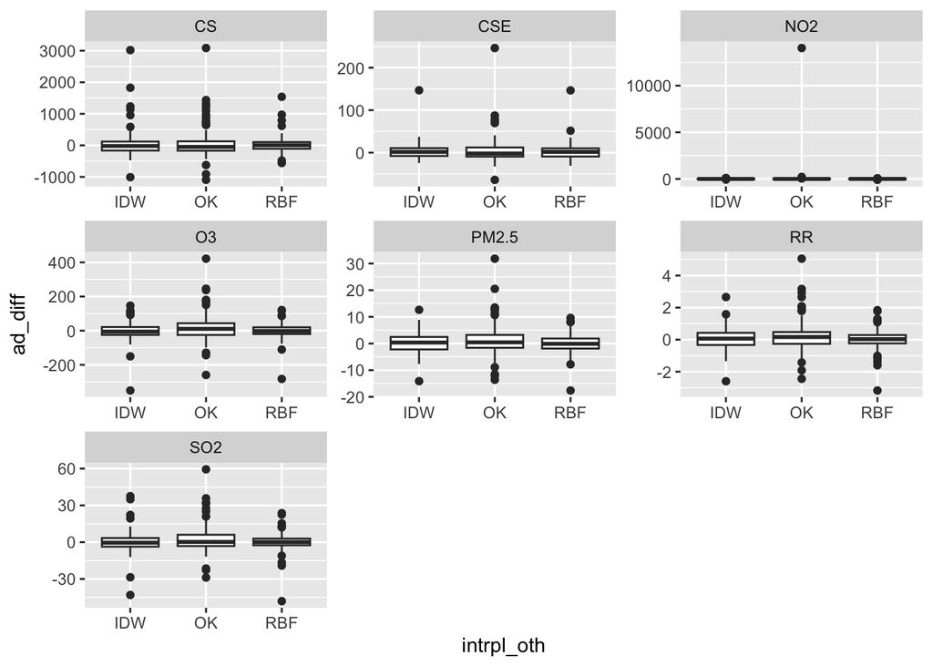

就把后面这个绝对误差配对差值的结果回复给平林吧，大意是： 从绝对误差来看，几种方法的差异比较微妙，只能根据MAE和RMSE的结果来选出最佳差值方法（支持数据为原文的corss-validation结果的表）。并且，说明为何只计算MAE和RMSE，而不计算绝对误差。